# TargetCNV-ML: Reporte de Entrenamiento y Evaluación de Modelos

CART (Escenario Balanceado): F1: 0.821 | ROC-AUC: 0.872 | Exactitud Bal.: 83.47% | Sensibilidad: 79.31% | Especificidad: 87.63% | Precisión: 85.19% | FDR: 14.81%

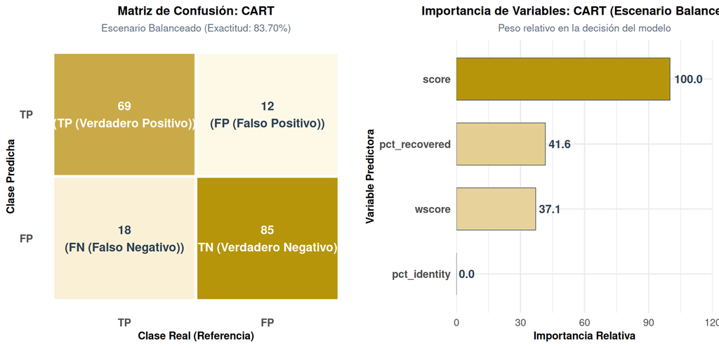

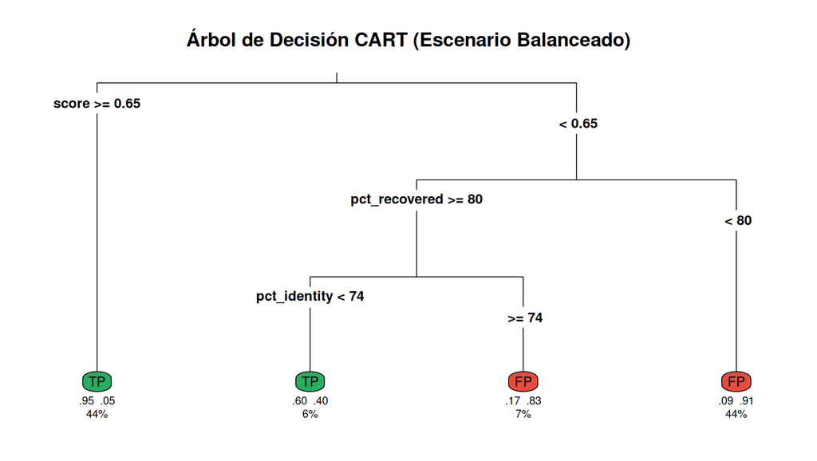

```
Hiperparámetros seleccionados en validación cruzada para CART (Escenario Balanceado):
  cp
1  0
```

**Stacked Autoencoder - DNN**

Stacked Autoencoder - DNN (Escenario Balanceado): F1: 0.533 | ROC-AUC: 0.549 | Exactitud Bal.: 50.05% | Sensibilidad: 60.92% | Especificidad: 39.18% | Precisión: 47.32% | FDR: 52.68%

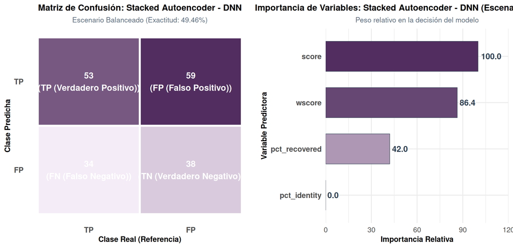

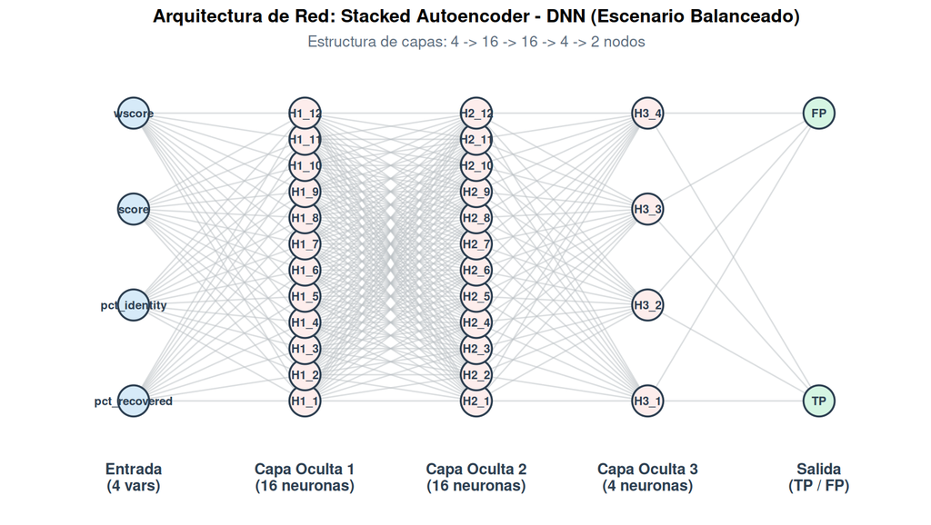

```
Hiperparámetros seleccionados en validación cruzada para Stacked Autoencoder - DNN (Escenario Balanceado):
  layer1 layer2 layer3 hidden_dropout visible_dropout
5     16     16      4              0               0
```

**Escenario Desbalanceado**

[interactive chart not shown]

**Ver Benchmark Completo de Todos los Métodos (Escenario Desbalanceado)**

[interactive chart not shown]

| Modelo | Mejor_Version_FDR | Exactitud | Exactitud_Balanceada | Sensibilidad | Especificidad | Precision | VPN | FDR | F1_Score | MCC | Kappa | ROC_AUC | TP | FP | FN | TN |
| --- | --- | --- | --- | --- | --- | --- | --- | --- | --- | --- | --- | --- | --- | --- | --- | --- |
| Ensamble_Stacking * | * Mejor en Balanceado (FDR: 7.69% vs 8.75% \| Índice: 0.887 vs 0.883) | 88.59 | 88.35 | 83.91 | 92.78 | 91.25 | 86.54 | 8.75 | 0.874 | 0.772 | 0.77 | 0.935 | 73 | 7 | 14 | 90 |
| NaiveBayes | Equivalente en ambos (FDR: 8.00%) | 86.96 | 86.56 | 79.31 | 93.81 | 92 | 83.49 | 8 | 0.852 | 0.743 | 0.736 | 0.934 | 69 | 6 | 18 | 91 |
| Youden_score | Invariante (regla fija) | 88.04 | 87.77 | 82.76 | 92.78 | 91.14 | 85.71 | 8.86 | 0.867 | 0.762 | 0.759 | 0.933 | 72 | 7 | 15 | 90 |
| SVM_Polinomial * | * Mejor en Balanceado (FDR: 7.89% vs 23.30% \| Índice: 0.880 vs 0.787) | 82.61 | 83.03 | 90.8 | 75.26 | 76.7 | 90.12 | 23.3 | 0.832 | 0.664 | 0.654 | 0.93 | 79 | 24 | 8 | 73 |
| ElasticNet | Óptimo en Desbalanceado (FDR: 14.12% vs 15.12% \| Índice: 0.842 vs 0.835) | 85.87 | 85.77 | 83.91 | 87.63 | 85.88 | 85.86 | 14.12 | 0.849 | 0.716 | 0.716 | 0.93 | 73 | 12 | 14 | 85 |
| Youden_wscore | Invariante (regla fija) | 86.96 | 86.8 | 83.91 | 89.69 | 87.95 | 86.14 | 12.05 | 0.859 | 0.738 | 0.738 | 0.928 | 73 | 10 | 14 | 87 |
| MLP | Óptimo en Desbalanceado (FDR: 8.00% vs 8.00% \| Índice: 0.875 vs 0.875) | 86.96 | 86.56 | 79.31 | 93.81 | 92 | 83.49 | 8 | 0.852 | 0.743 | 0.736 | 0.925 | 69 | 6 | 18 | 91 |
| SVM_Lineal | Óptimo en Desbalanceado (FDR: 10.98% vs 13.10% \| Índice: 0.865 vs 0.850) | 87.5 | 87.31 | 83.91 | 90.72 | 89.02 | 86.27 | 10.98 | 0.864 | 0.75 | 0.749 | 0.923 | 73 | 9 | 14 | 88 |
| Red_Neuronal_Bag | Óptimo en Desbalanceado (FDR: 7.69% vs 10.00% \| Índice: 0.886 vs 0.870) | 88.59 | 88.29 | 82.76 | 93.81 | 92.31 | 85.85 | 7.69 | 0.873 | 0.774 | 0.77 | 0.922 | 72 | 6 | 15 | 91 |
| LDA | Óptimo en Desbalanceado (FDR: 10.00% vs 11.11% \| Índice: 0.869 vs 0.861) | 87.5 | 87.26 | 82.76 | 91.75 | 90 | 85.58 | 10 | 0.862 | 0.75 | 0.748 | 0.922 | 72 | 8 | 15 | 89 |

[output cut: 14 more lines]

#### 3.0.2 Matrices de Confusión e Importancia de Variables (Escenario Desbalanceado)

**Resumen: Top 6 (2 Youden + Heurístico + 3 ML)**

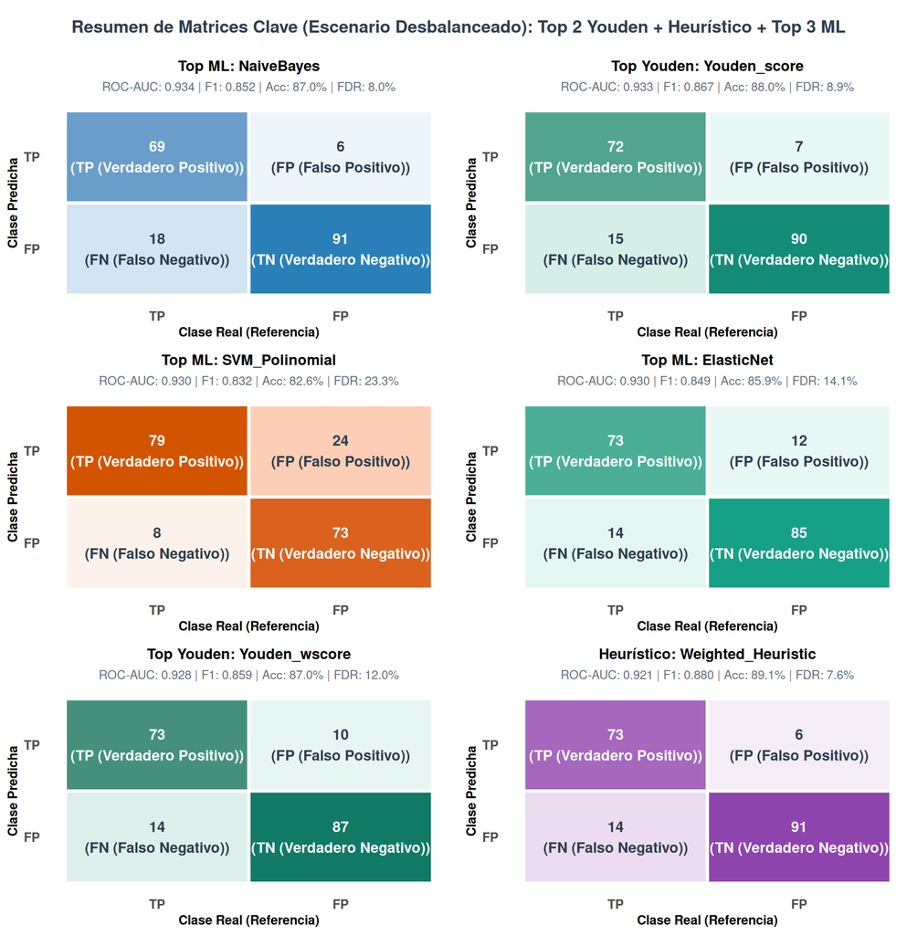

**Ensamble_Stacking**

Ensamble_Stacking (Escenario Desbalanceado): F1: 0.874 | ROC-AUC: 0.935 | Exactitud Bal.: 88.35% | Sensibilidad: 83.91% | Especificidad: 92.78% | Precisión: 91.25% | FDR: 8.75%

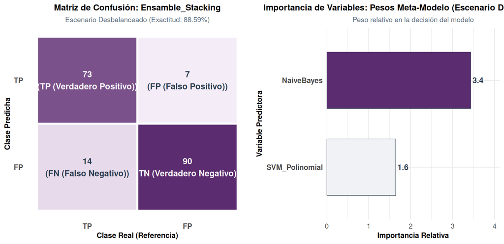

```
Resumen del Meta-Modelo GLM Stacking (Escenario Desbalanceado):
The following models were ensembled: NaiveBayes, SVM_Polinomial

caret::train model:
Generalized Linear Model

184 samples
  2 predictor
  2 classes: 'TP', 'FP'

No pre-processing
Resampling: Cross-Validated (5 fold)
Summary of sample sizes: 146, 148, 146, 148, 148
Resampling results:

  ROC        Sens       Spec
  0.9369573  0.8281046  0.9063158


Final model:

Call:  NULL

Coefficients:
   (Intercept)      NaiveBayes  SVM_Polinomial
        -2.628           3.434           1.645

Degrees of Freedom: 183 Total (i.e. Null);  181 Residual
Null Deviance:      254.5
Residual Deviance: 125  AIC: 131
```

**NaiveBayes**

NaiveBayes (Escenario Desbalanceado): F1: 0.852 | ROC-AUC: 0.934 | Exactitud Bal.: 86.56% | Sensibilidad: 79.31% | Especificidad: 93.81% | Precisión: 92.00% | FDR: 8.00%

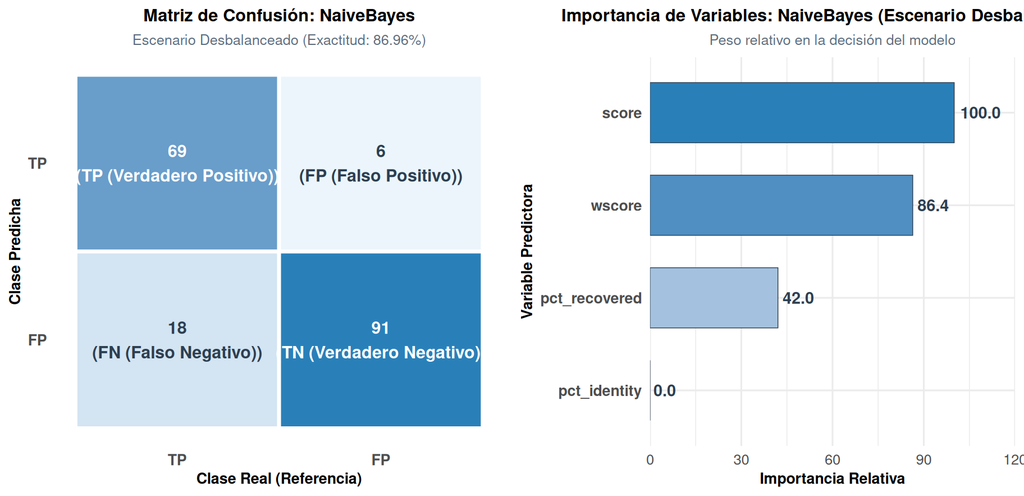

```
Hiperparámetros seleccionados en validación cruzada para NaiveBayes (Escenario Desbalanceado):
  fL usekernel adjust
2  0      TRUE      1
```

**Youden_score**

Youden_score (Escenario Desbalanceado): F1: 0.867 | ROC-AUC: 0.933 | Exactitud Bal.: 87.77% | Sensibilidad: 82.76% | Especificidad: 92.78% | Precisión: 91.14% | FDR: 8.86%

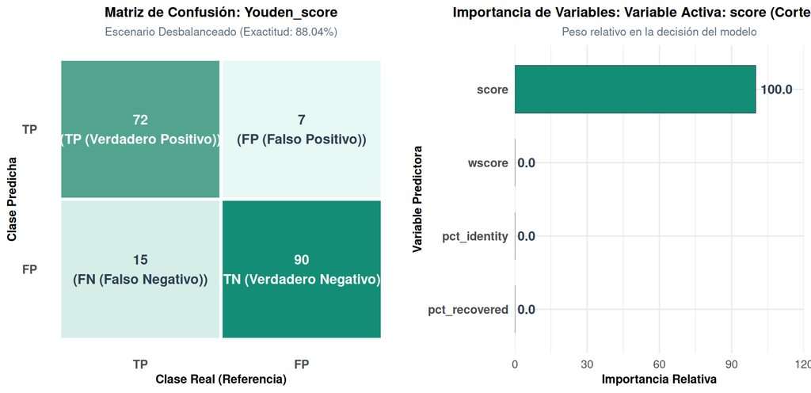

**SVM_Polinomial**

SVM_Polinomial (Escenario Desbalanceado): F1: 0.832 | ROC-AUC: 0.930 | Exactitud Bal.: 83.03% | Sensibilidad: 90.80% | Especificidad: 75.26% | Precisión: 76.70% | FDR: 23.30%

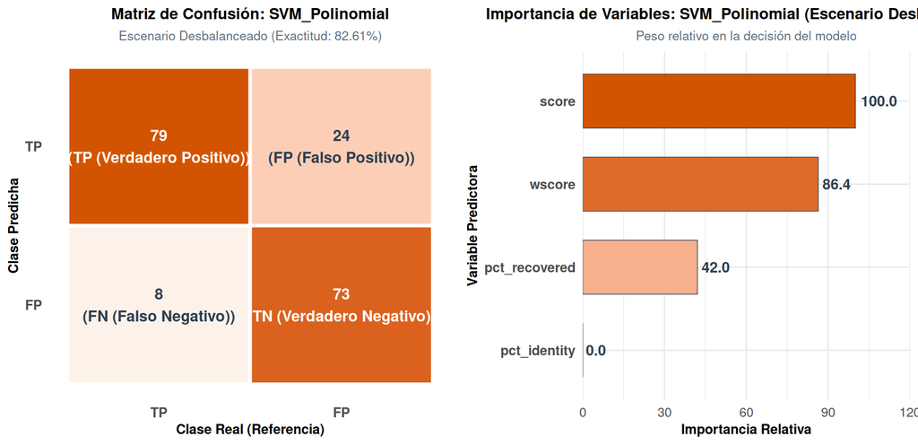

```
Hiperparámetros seleccionados en validación cruzada para SVM_Polinomial (Escenario Desbalanceado):
  degree scale    C
1      1 0.001 0.25
```

**ElasticNet**

ElasticNet (Escenario Desbalanceado): F1: 0.849 | ROC-AUC: 0.930 | Exactitud Bal.: 85.77% | Sensibilidad: 83.91% | Especificidad: 87.63% | Precisión: 85.88% | FDR: 14.12%

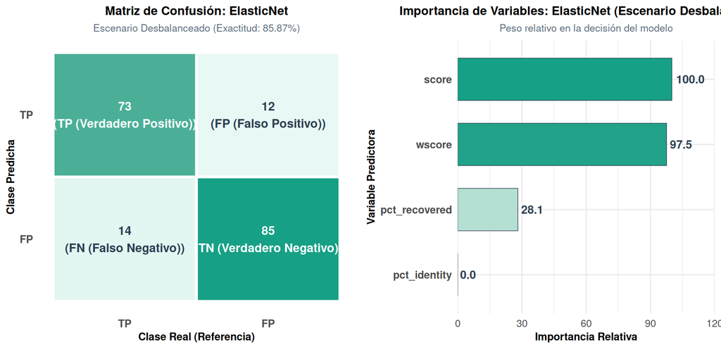

```
Hiperparámetros óptimos Elastic Net (Escenario Desbalanceado): alpha = 0.1 | lambda = 0.168
5 x 1 sparse Matrix of class "dgCMatrix"
              s=0.1679815
(Intercept)     0.1509173
pct_recovered  -0.3767360
pct_identity   -0.3537959
score          -0.4353887
wscore         -0.4333740
```

**Youden_wscore**

Youden_wscore (Escenario Desbalanceado): F1: 0.859 | ROC-AUC: 0.928 | Exactitud Bal.: 86.80% | Sensibilidad: 83.91% | Especificidad: 89.69% | Precisión: 87.95% | FDR: 12.05%

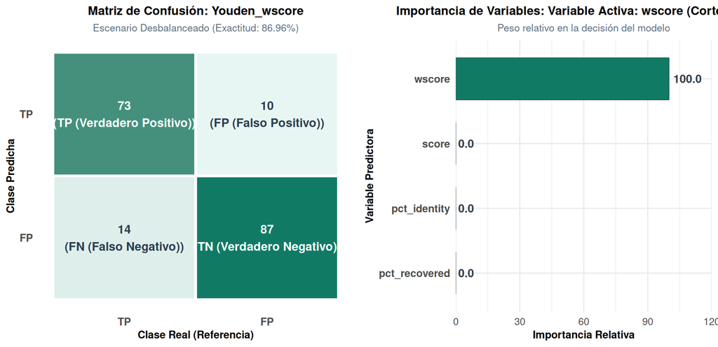

**MLP**

MLP (Escenario Desbalanceado): F1: 0.852 | ROC-AUC: 0.925 | Exactitud Bal.: 86.56% | Sensibilidad: 79.31% | Especificidad: 93.81% | Precisión: 92.00% | FDR: 8.00%

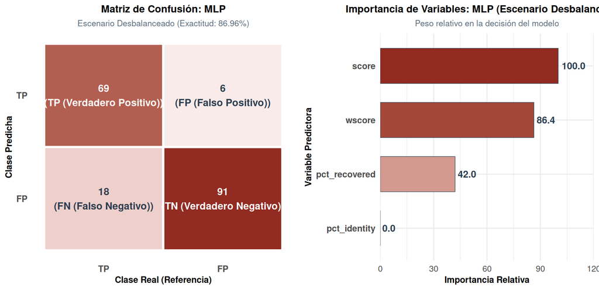

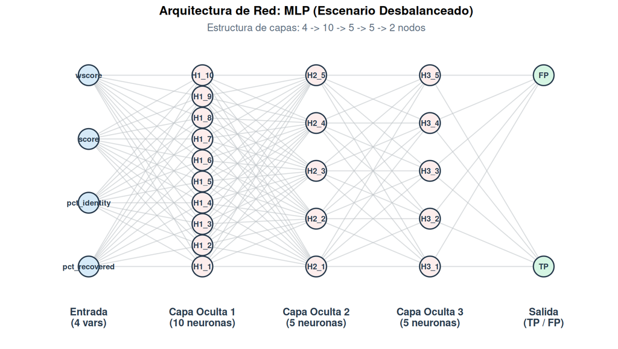

```
Hiperparámetros seleccionados en validación cruzada para MLP (Escenario Desbalanceado):
  layer1 layer2 layer3
2     10      5      5
```

**SVM_Lineal**

SVM_Lineal (Escenario Desbalanceado): F1: 0.864 | ROC-AUC: 0.923 | Exactitud Bal.: 87.31% | Sensibilidad: 83.91% | Especificidad: 90.72% | Precisión: 89.02% | FDR: 10.98%

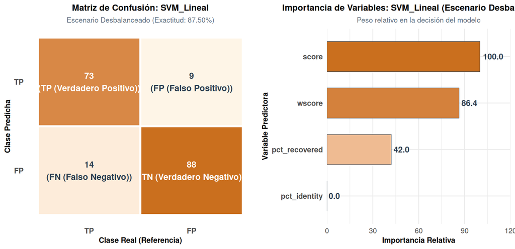

```
Hiperparámetros seleccionados en validación cruzada para SVM_Lineal (Escenario Desbalanceado):
  C
1 1
```

**Red_Neuronal_Bag**

Red_Neuronal_Bag (Escenario Desbalanceado): F1: 0.873 | ROC-AUC: 0.922 | Exactitud Bal.: 88.29% | Sensibilidad: 82.76% | Especificidad: 93.81% | Precisión: 92.31% | FDR: 7.69%

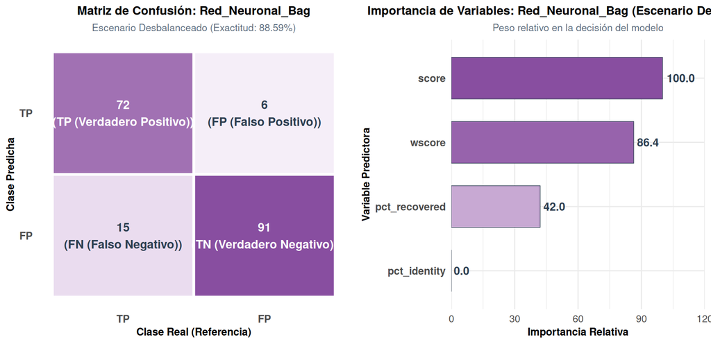

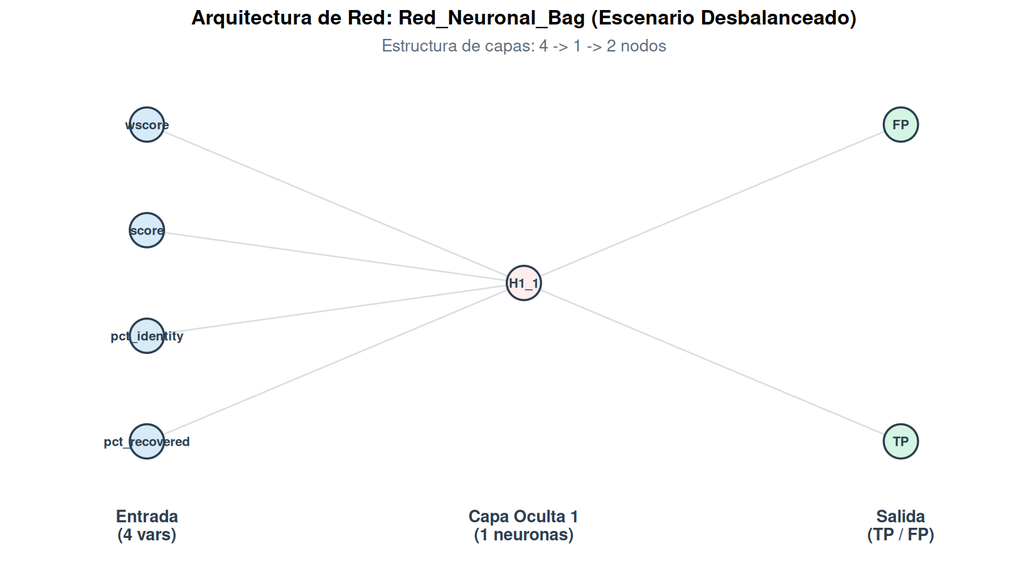

```
Parámetros de Red_Neuronal_Bag (avNNet - Escenario Desbalanceado): sub-redes = 5 | topología = 4 - 1 - 2 | size = 1 | decay = 0.1
```

**LDA**

LDA (Escenario Desbalanceado): F1: 0.862 | ROC-AUC: 0.922 | Exactitud Bal.: 87.26% | Sensibilidad: 82.76% | Especificidad: 91.75% | Precisión: 90.00% | FDR: 10.00%

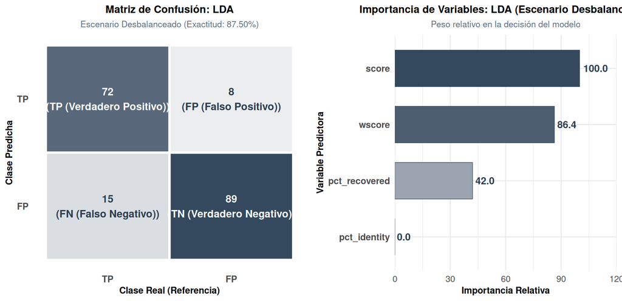

```
Coeficientes discriminantes lineales LD1 (Escenario Desbalanceado):
                     LD1
pct_recovered  0.6339534
pct_identity   1.7507420
score         -0.4909886
wscore        -3.3519645
```

**GBM**

GBM (Escenario Desbalanceado): F1: 0.848 | ROC-AUC: 0.921 | Exactitud Bal.: 86.11% | Sensibilidad: 80.46% | Especificidad: 91.75% | Precisión: 89.74% | FDR: 10.26%

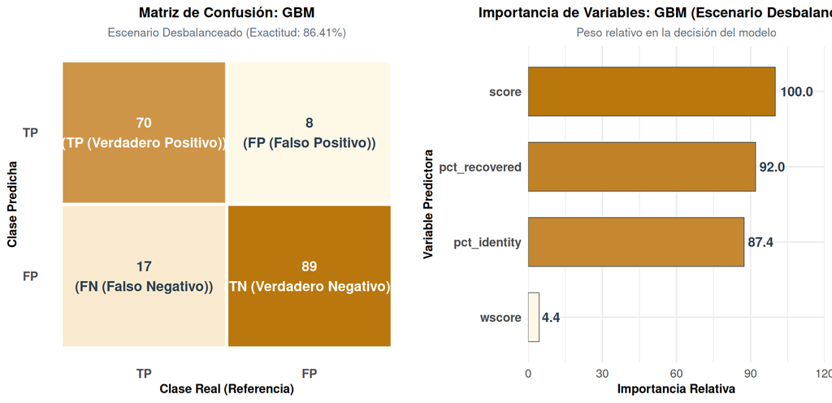

```
Hiperparámetros seleccionados en validación cruzada para GBM (Escenario Desbalanceado):
  n.trees interaction.depth shrinkage n.minobsinnode
2     100                 1      0.05             10
```

**MLP_Regularizado**

MLP_Regularizado (Escenario Desbalanceado): F1: 0.873 | ROC-AUC: 0.921 | Exactitud Bal.: 88.29% | Sensibilidad: 82.76% | Especificidad: 93.81% | Precisión: 92.31% | FDR: 7.69%

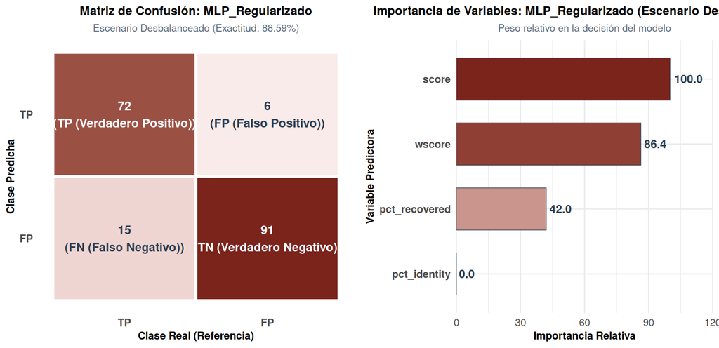

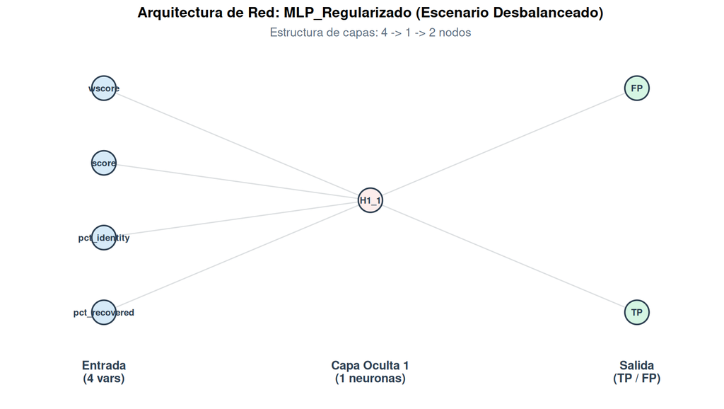

```
Hiperparámetros seleccionados en validación cruzada para MLP_Regularizado (Escenario Desbalanceado):
  layer1 layer2 layer3 decay
2      1      0      0 1e-04
```

**Red_Neuronal**

Red_Neuronal (Escenario Desbalanceado): F1: 0.833 | ROC-AUC: 0.921 | Exactitud Bal.: 84.56% | Sensibilidad: 80.46% | Especificidad: 88.66% | Precisión: 86.42% | FDR: 13.58%

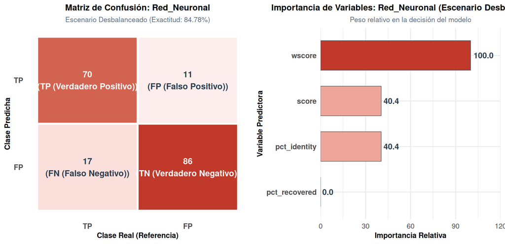

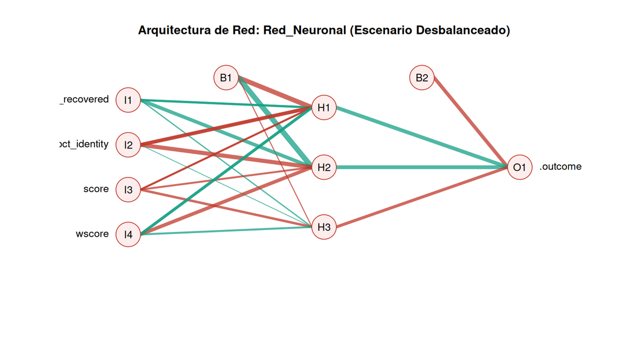

```
Parámetros de Red_Neuronal (nnet - Escenario Desbalanceado): topología = 4 - 3 - 1 | size = 3 | decay = 0
```

**Weighted_Heuristic**

Weighted_Heuristic (Escenario Desbalanceado): F1: 0.880 | ROC-AUC: 0.921 | Exactitud Bal.: 88.86% | Sensibilidad: 83.91% | Especificidad: 93.81% | Precisión: 92.41% | FDR: 7.59%

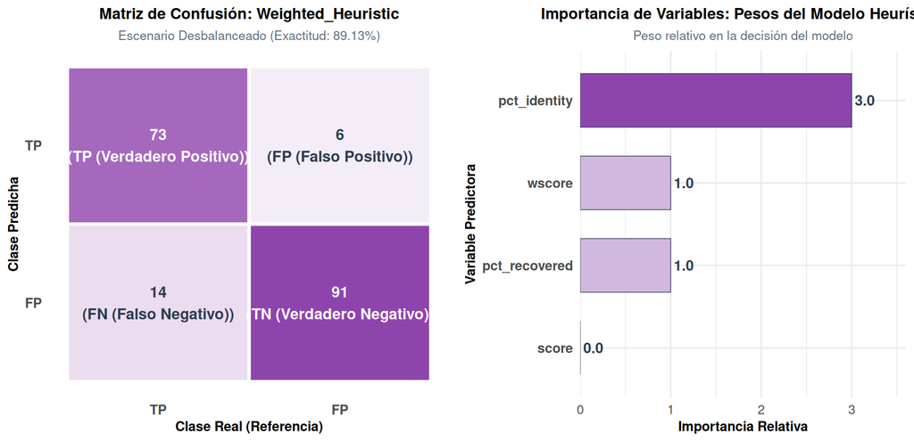

**QDA**

QDA (Escenario Desbalanceado): F1: 0.847 | ROC-AUC: 0.918 | Exactitud Bal.: 85.71% | Sensibilidad: 82.76% | Especificidad: 88.66% | Precisión: 86.75% | FDR: 13.25%

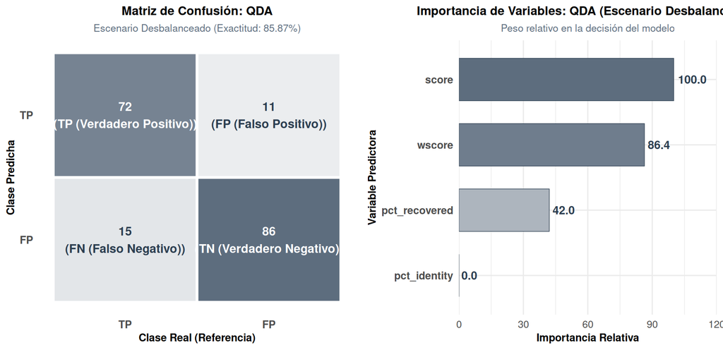

```
Hiperparámetros seleccionados en validación cruzada para QDA (Escenario Desbalanceado):
  parameter
1      none
```

**XGBoost**

XGBoost (Escenario Desbalanceado): F1: 0.833 | ROC-AUC: 0.918 | Exactitud Bal.: 84.56% | Sensibilidad: 80.46% | Especificidad: 88.66% | Precisión: 86.42% | FDR: 13.58%

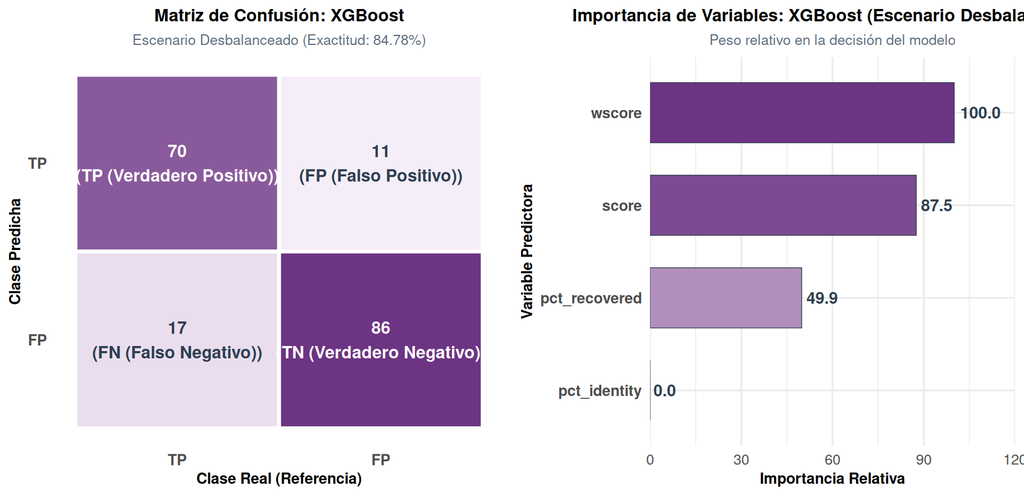

```
Hiperparámetros seleccionados en validación cruzada para XGBoost (Escenario Desbalanceado):
  nrounds max_depth eta gamma colsample_bytree min_child_weight subsample
1      50         1 0.3     0              0.6                1       0.5
```

**Youden_pct_recovered**

Youden_pct_recovered (Escenario Desbalanceado): F1: 0.865 | ROC-AUC: 0.914 | Exactitud Bal.: 87.37% | Sensibilidad: 85.06% | Especificidad: 89.69% | Precisión: 88.10% | FDR: 11.90%

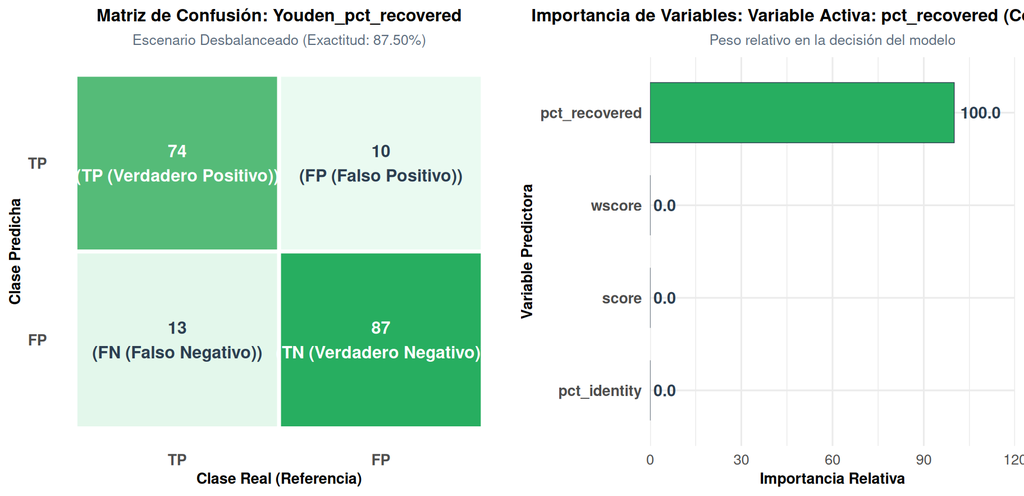

**KNN**

KNN (Escenario Desbalanceado): F1: 0.841 | ROC-AUC: 0.911 | Exactitud Bal.: 85.53% | Sensibilidad: 79.31% | Especificidad: 91.75% | Precisión: 89.61% | FDR: 10.39%

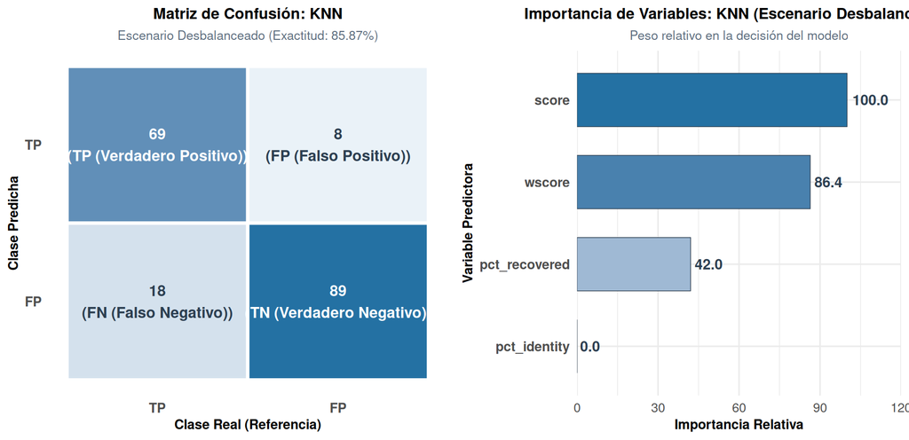

```
Hiperparámetros seleccionados en validación cruzada para KNN (Escenario Desbalanceado):
  k
2 7
```

**CART**

CART (Escenario Desbalanceado): F1: 0.839 | ROC-AUC: 0.903 | Exactitud Bal.: 84.74% | Sensibilidad: 83.91% | Especificidad: 85.57% | Precisión: 83.91% | FDR: 16.09%

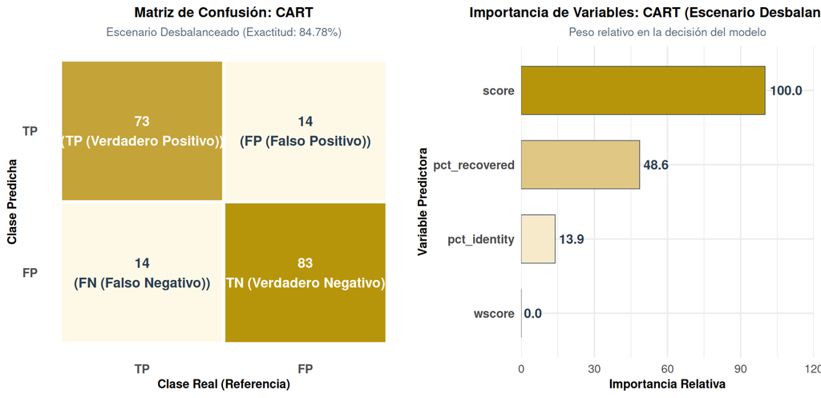

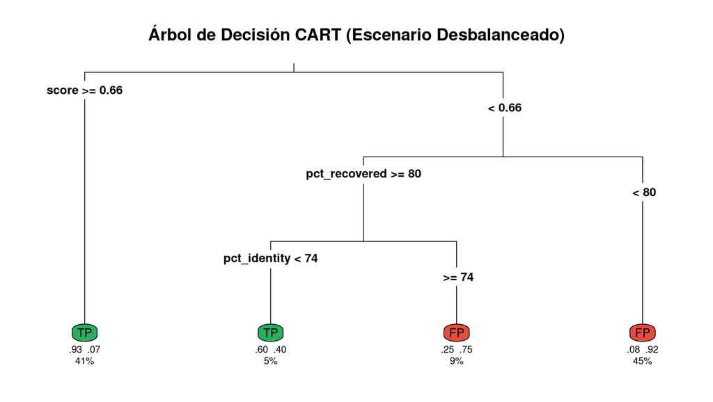

```
Hiperparámetros seleccionados en validación cruzada para CART (Escenario Desbalanceado):
  cp
1  0
```

**RandomForest**

RandomForest (Escenario Desbalanceado): F1: 0.826 | ROC-AUC: 0.902 | Exactitud Bal.: 83.99% | Sensibilidad: 79.31% | Especificidad: 88.66% | Precisión: 86.25% | FDR: 13.75%

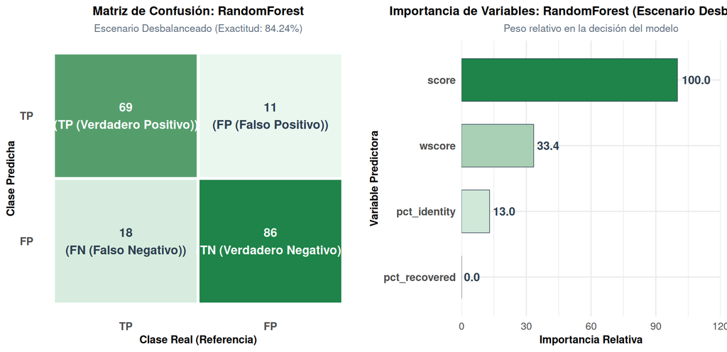

```
Hiperparámetros seleccionados en validación cruzada para RandomForest (Escenario Desbalanceado):
  mtry
1    2
```

**Bagging_Arboles**

Bagging_Arboles (Escenario Desbalanceado): F1: 0.812 | ROC-AUC: 0.902 | Exactitud Bal.: 82.84% | Sensibilidad: 77.01% | Especificidad: 88.66% | Precisión: 85.90% | FDR: 14.10%

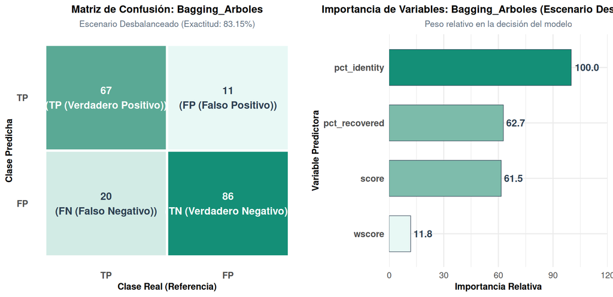

```
Hiperparámetros seleccionados en validación cruzada para Bagging_Arboles (Escenario Desbalanceado):
  parameter
1      none
```

**SVM_Radial**

SVM_Radial (Escenario Desbalanceado): F1: 0.830 | ROC-AUC: 0.902 | Exactitud Bal.: 84.84% | Sensibilidad: 75.86% | Especificidad: 93.81% | Precisión: 91.67% | FDR: 8.33%

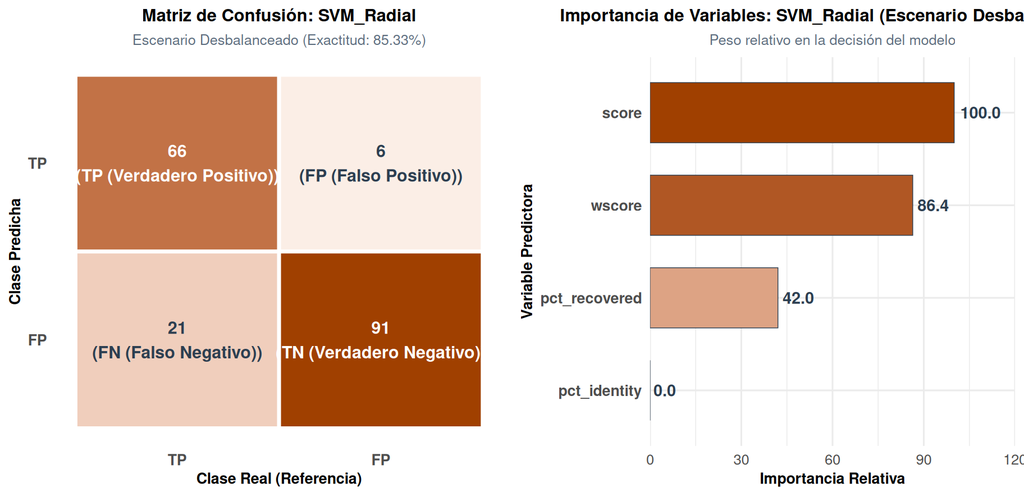

```
Hiperparámetros seleccionados en validación cruzada para SVM_Radial (Escenario Desbalanceado):
     sigma    C
1 1.842564 0.25
```

**Youden_pct_identity**

Youden_pct_identity (Escenario Desbalanceado): F1: 0.840 | ROC-AUC: 0.901 | Exactitud Bal.: 86.21% | Sensibilidad: 72.41% | Especificidad: 100.00% | Precisión: 100.00% | FDR: 0.00%

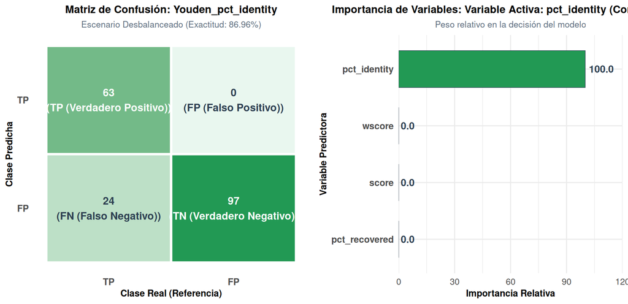

**Stacked Autoencoder - DNN**

Stacked Autoencoder - DNN (Escenario Desbalanceado): F1: NA | ROC-AUC: 0.557 | Exactitud Bal.: 50.00% | Sensibilidad: 0.00% | Especificidad: 100.00% | Precisión: NA | FDR: NA

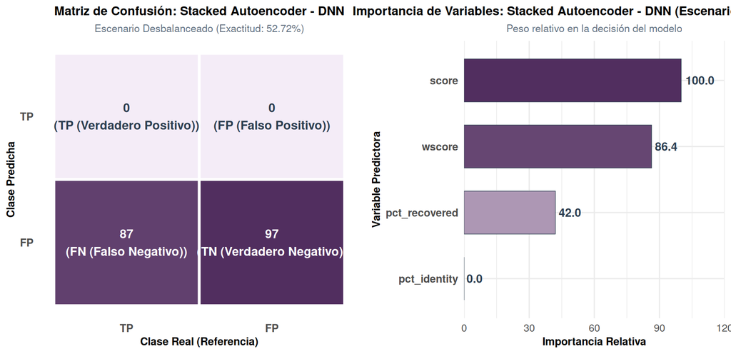

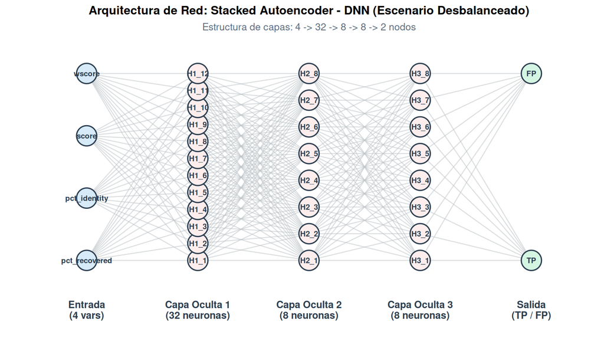

```
Hiperparámetros seleccionados en validación cruzada para Stacked Autoencoder - DNN (Escenario Desbalanceado):
   layer1 layer2 layer3 hidden_dropout visible_dropout
12     32      8      8            0.1               0
```

## 4 Explicabilidad Aditiva KernelSHAP

La descomposición de valores de Shapley cuantifica el aporte marginal de cada predictor continuo sobre la probabilidad predicha de homólogo válido $P(\text{TP})$ en `ElasticNet`.

**Importancia Global SHAP (Beeswarm e Importancia Media)**

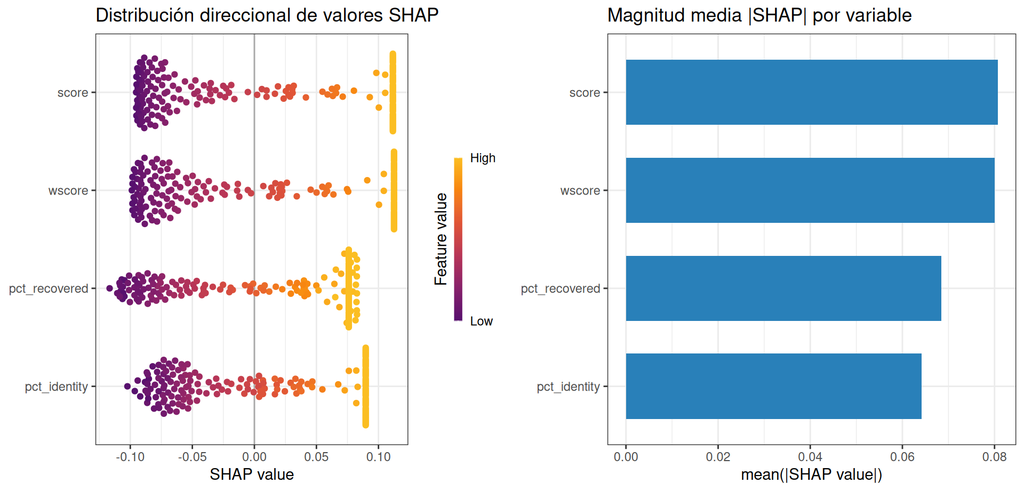

**Explorador Individual por Secuencia (Waterfall Interactivo)**

Filtrar por Clase Real:

Seleccionar Fila / Gen: